# Alinhamento dos parlamentares com posições de Meio Ambiente

Com base em votações realizadas na legislatura 15-18, voltadas para o tema de **Meio Ambiente**, estamos buscando analisar o alinhamento de **Deputados Federais**, **partidos** e **Comissões** com relação a este tema. Para definir o alinhamento do parlamentar é preciso **comparar suas posições** (votos em propostas específicas) com as posições ideais dos defensores do Meio Ambiente.

### Sobre as votações

Foram selecionadas 7 votações importantes para calcular o alinhamento dos parlamentares.

- **[PL 4148/2008](https://www.camara.leg.br/proposicoesWeb/fichadetramitacao?idProposicao=412728): Fim à Rotulagem de Alimentos Transgênicos**. A [votação](https://www.camara.leg.br/internet/votacao/mostraVotacao.asp?ideVotacao=6259&numLegislatura=55&codCasa=1&numSessaoLegislativa=1&indTipoSessaoLegislativa=O&numSessao=88&indTipoSessao=E&tipo=uf) usada é da Subemenda Substitutiva da CDEIC.
- **[MPV 688/2015](https://www.camara.leg.br/proposicoesWeb/fichadetramitacao?idProposicao=1672065): Permissão ao Governo de cobrar outorgas no leilão de usinas hidrelétricas e o autoriza a apoiar hidrelétricas após perdas causadas pela seca**. A [votação](https://www.camara.leg.br/internet/votacao/mostraVotacao.asp?ideVotacao=6706&numLegislatura=55&codCasa=1&numSessaoLegislativa=1&indTipoSessaoLegislativa=O&numSessao=346&indTipoSessao=E&tipo=partido) usada é do Projeto de Lei de conversão.
- **[MPV 756/2016](https://www.camara.leg.br/proposicoesWeb/fichadetramitacao?idProposicao=2121839): Redução da proteção ambiental na Floresta do Jamanxim**. A [votação](https://www.camara.leg.br/internet/votacao/mostraVotacao.asp?ideVotacao=7542&numLegislatura=55&codCasa=1&numSessaoLegislativa=3&indTipoSessaoLegislativa=O&numSessao=118&indTipoSessao=E&tipo=uf) usada é do Parecer da Comissão Mista.
- **[MPV 758/2016](https://www.camara.leg.br/proposicoesWeb/fichadetramitacao?idProposicao=2121849): Redução do Parque Nacional do Jamanxim**. A [votação](https://www.camara.leg.br/internet/votacao/mostraVotacao.asp?ideVotacao=7556&numLegislatura=55&codCasa=1&numSessaoLegislativa=3&indTipoSessaoLegislativa=O&numSessao=119&indTipoSessao=E&tipo=uf) é do Parecer da Comissão Mista.
- **[EMC 96/2017](https://www.camara.leg.br/proposicoesWeb/fichadetramitacao?idProposicao=2125339): Regulamentação das Vaquejadas**. A [votação](https://www.camara.leg.br/internet/votacao/mostraVotacao.asp?ideVotacao=7603&numLegislatura=55&codCasa=1&numSessaoLegislativa=3&indTipoSessaoLegislativa=O&numSessao=142&indTipoSessao=E&tipo=partido) é a votação da PEC já no segundo turno.
- **[MPV 759/2016](https://www.camara.leg.br/proposicoesWeb/fichadetramitacao?idProposicao=2122078): Regularização fundiária sobre a liquidação de créditos concedidos aos assentados da reforma agrária e sobre a regularização fundiária no âmbito da Amazônia Legal**. A [votação](https://www.camara.leg.br/internet/votacao/mostraVotacao.asp?ideVotacao=7630&numLegislatura=55&codCasa=1&numSessaoLegislativa=3&indTipoSessaoLegislativa=O&numSessao=170&indTipoSessao=E&tipo=partido) é da Emenda do Senado Federal.
- **[MPV 809/2017](https://www.camara.leg.br/proposicoesWeb/fichadetramitacao?idProposicao=2164234): Regulamentação da Forma de Pagamento da Compensação Ambiental em Unidades de Conservação**. A [votação](https://www.camara.leg.br/internet/votacao/mostraVotacao.asp?ideVotacao=8306&numLegislatura=55&codCasa=1&numSessaoLegislativa=4&indTipoSessaoLegislativa=O&numSessao=88&indTipoSessao=E&tipo=uf) é do Parecer da Comissão Mista.

### O que é alinhamento?

Para calcular o alinhamento de um parlamentar é preciso calcular 3 informações principais:

- Quantidade de **respostas iguais**, ou seja, quando o parlamentar votou exatamente como um defensor dos interesses do Meio Ambiente votaria;
- Quantidade de **posições dadas**, isto é, o número de votações que o parlamentar participou/se posicionou;
- Quantidade **posições não dadas**, que corresponde ao número de vezes que o parlamentar faltou a sessão e não pode se posicionar a favor do meio ambiente.

Com essas informações o cálculo do alinhamento é dado por: **respostas iguais / (posições dadas + posições não dadas)**. Foi considerado nessa análise que caso o parlamentar vote por obstruir a votação, está portanto votando contra a mesma. Votos de abstenção não foram considerados. O alinhamento só é calculado se o parlamentar tiver votado em pelos menos 3 votações.

## Análise dos Deputados Federais com maior alinhamento ao Meio Ambiente

Calculamos o alinhamento para os Deputados Federais que participaram de alguma das 7 votações selecionadas. Em seguida, filtramos essa lista de deputados para considerar apenas os que estão atualmente em exercício. A partir deste ponto, consideraremos apenas os deputados em exercício. A visualização a seguir mostra a distribuição desses deputados com relação a variável de alinhamento.

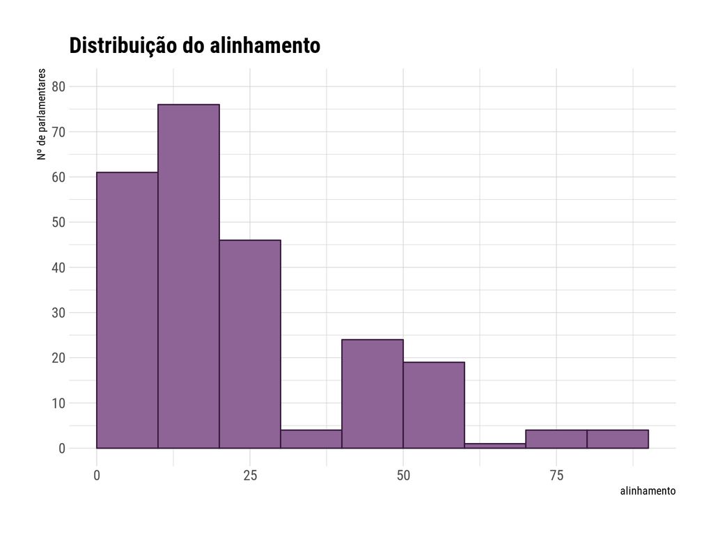

Pela visualização é possível perceber que existem poucos parlamentares acima dos 50% de alinhamento com Meio Ambiente. Apenas 28 dos 239 estão acima de 50%, o que corresponde a 0.12 dos deputados atualmente em exercício e que também participaram da legislatura passada (15-18).

É visível que a maior parte dos deputados se concentra na faixa de alinhamento entre 0% e 30%.

### Quem são os parlamentares mais alinhados ao meio ambiente?

Agora que já conhecemos a distribuição dos dados de alinhamento, sabemos que existem alguns poucos parlamentares com alinhamento ao Meio Ambiente considerado alto. Os 25 com maior alinhamento estão listados a seguir.

- A **barra azul** indica a quantidade de votações nas quais o **deputado votou exatamente alinhado** aos interesses do Meio Ambiente votaria.
- A **barra vermelha** indica a quantidade de votações nas quais o **deputado foi contrário aos interesses** do Meio Ambiente.
- A **barra laranja** indica a quantidade votações nas quais o **deputado não compareceu para defender** a posição de interesse do Meio Ambiente.

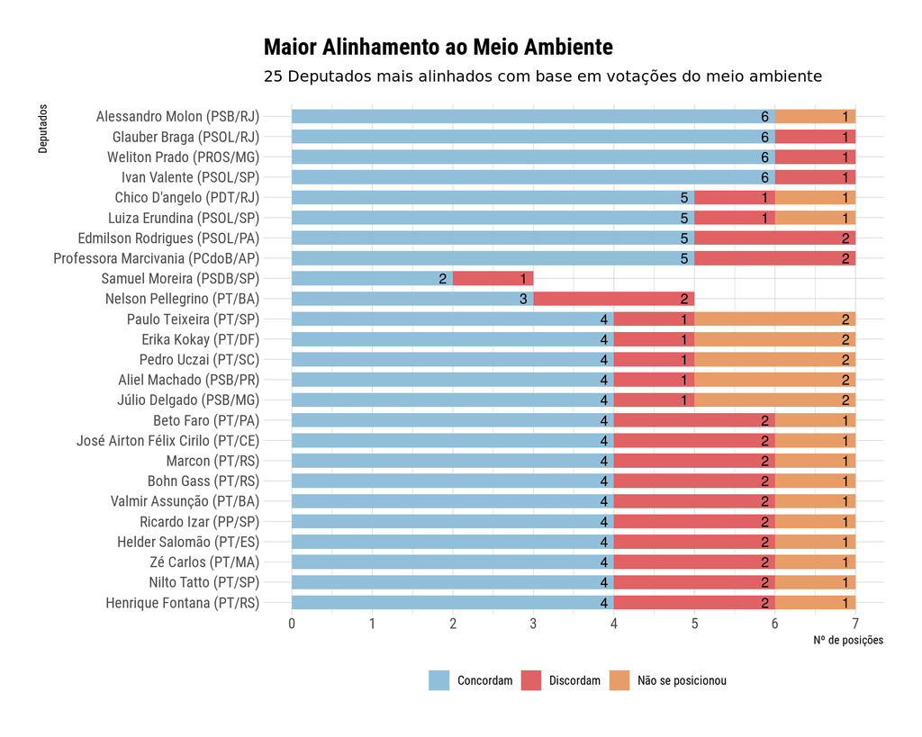

Destacam-se nessa visualização os 4 primeiros deputados que votaram de acordo com os interesses do Meio Ambiente em 6 das 7 oportunidades que tiveram.

Outros 3 deputados também tiveram alinhamento igual a 57% e estariam empatados com outros parlamentares nessa visualização, são eles: Vander Loubet (PT/MS), João Daniel (PT/SE) e Vicentinho (PT/SP).

As barras de Samuel Moreira (PSDB/SP) e de Nelson Pellegrino (PT/BA) são menores pois ambos não participaram de algumas votações no período analisado (legislatura 15-18). Segundo suas biografias na Câmara ([aqui](https://www.camara.leg.br/deputados/178990/biografia) e [aqui](https://www.camara.leg.br/deputados/74571/biografia)) eles estavam de licença para assumir cargos de Secretários em seus respectivos estados.

### Quem são os parlamentares menos alinhados ao meio ambiente?

Se olharmos para o final da lista de deputados, temos acesso aos que estão menos alinhados ao Meio Ambiente. Todos os 25 deputados mostrados a seguir possuem alinhamento de 0%, ou seja, não votaram favorável ao Meio Ambiente em nenhuma das 7 votações escolhidas para esta análise.

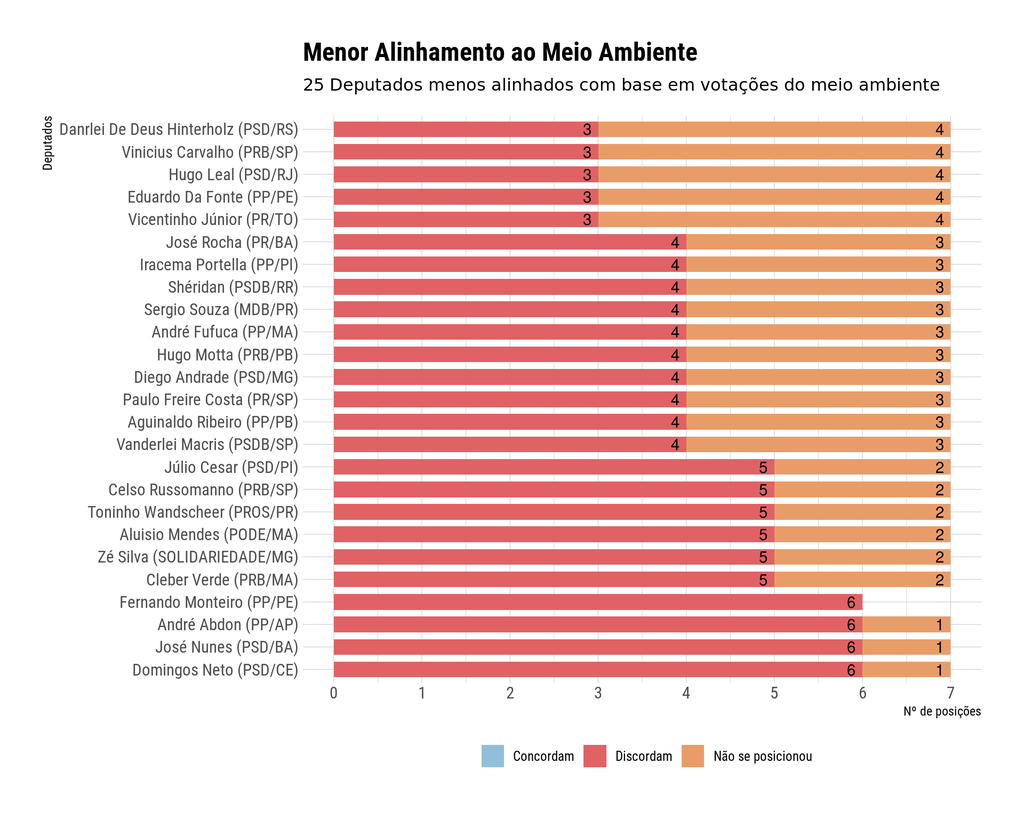

É possível destacar nessa visualização os 4 parlamentares que votaram de forma desfavorável aos interesses do Meio Ambiente em 6 das 7 votações escolhidas. São eles: Domingos Neto (PSD/CE), José Nunes (PSD/BA), André Abdon (PP/AP), Fernando Monteiro (PP/PE).

Houveram 61 deputados com alinhamento igual a 0, isto é, sem posições favoráveis ao Meio Ambiente.

Buscando responder a pergunta de **Como membros ligados ao Governo Bolsonaro se posicionaram em votações relacionadas ao Meio Ambiente?**, a visualização a seguir apresenta membros ligados diretamente ao Governo Bolsonaro, como o próprio Presidente Jair Bolsonaro e seu ministro da Casa Civil Onyx Lorenzoni. Também incluímos o presidente atual da Câmara dos Deputados: Rodrigo Maia.

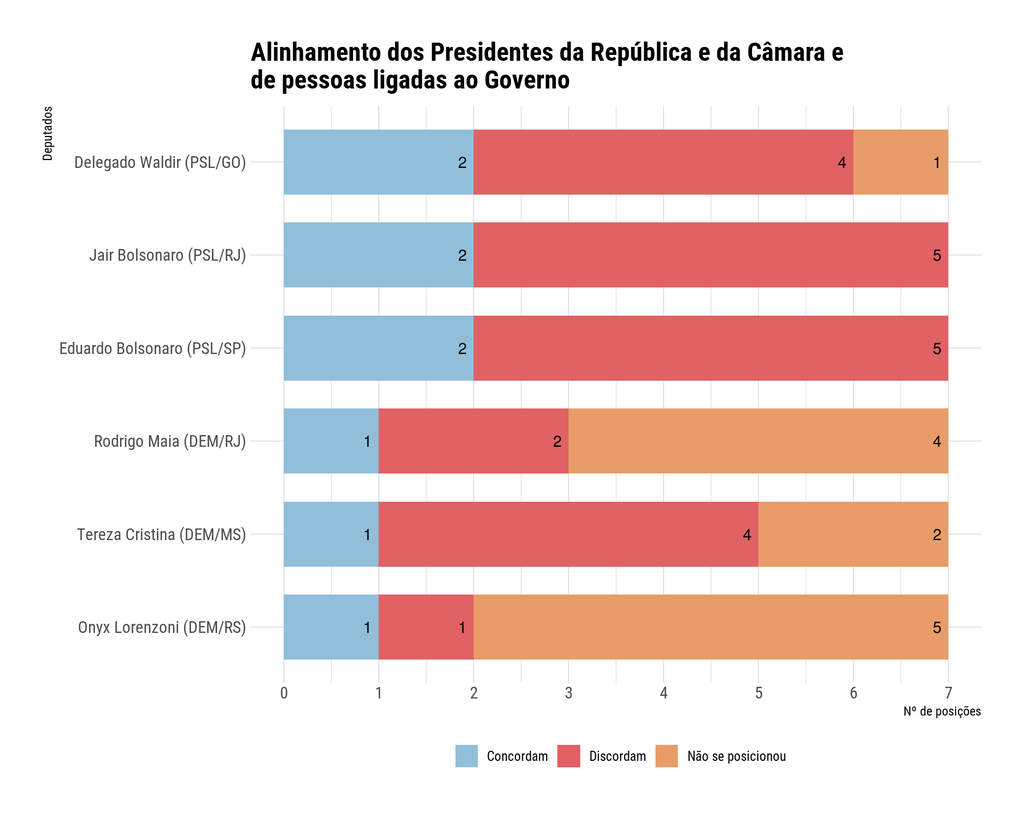

Nenhum membro desse grupo ultrapassa o valor de 30% de alinhamento.

## Alinhamento dos Partidos ao Meio Ambiente

Abaixo são apresentados os alinhamentos dos partidos parlamentares, baseados em suas orientações em cada uma das 7 votações do Meio Ambiente. É importante ressaltar que os blocos parlamentares são dissolvidos, transformando-se em um conjunto separado de partidos que os compõem e a orientação é mantida.

Outro ponto a se informar é que os partidos em titulados de Governo, Maioria e Minoria dizem respeito aos blocos parlamentares da 55ª legislatura, que vai de 2015 a 2018.

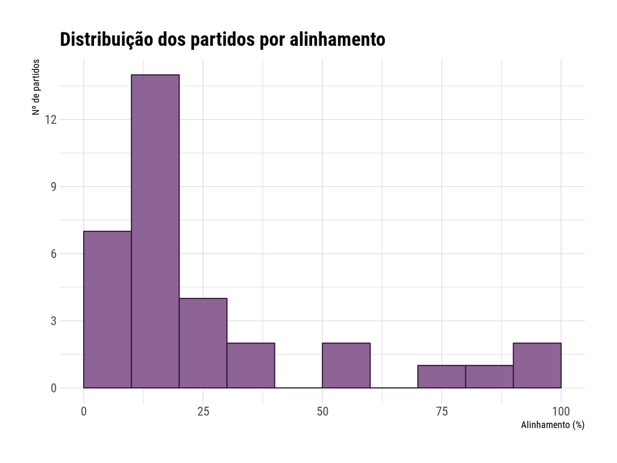

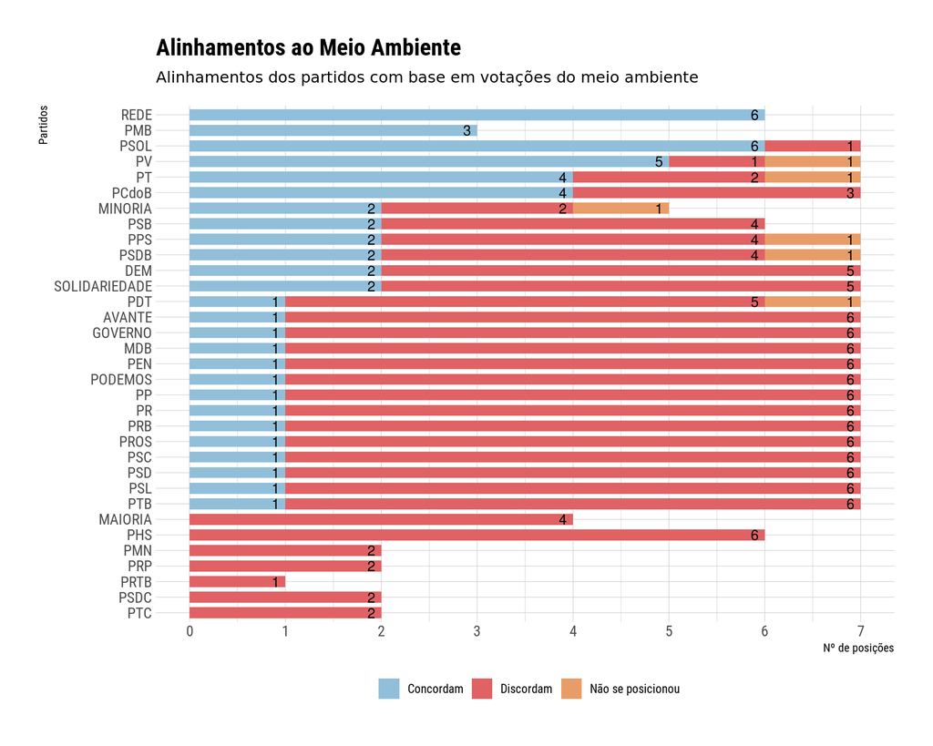

Observação: Abaixo listam-se os motivos pelos quais não há todas as orientações dos partidos:

- REDE: a votação da [PL 4148/2008](https://www.camara.leg.br/internet/votacao/mostraVotacao.asp?ideVotacao=6259&numLegislatura=55&codCasa=1&numSessaoLegislativa=1&indTipoSessaoLegislativa=O&numSessao=88&indTipoSessao=E&tipo=partido) faltante ocorreu antes do seu registro definitivo, concedido em 22/09/2015;
- PMB: Não possui quatro votações: duas delas ocorreram antes de haver alguma filiação dos deputados, evento acontecido apenas em 18/11/2015; em uma delas (EMC 96/2017) não houve orientação do partido, mas Weliton Prado, único filiado do PMB, votou [Sim](https://www.camara.leg.br/internet/votacao/mostraVotacao.asp?ideVotacao=7603&numLegislatura=55&codCasa=1&numSessaoLegislativa=3&indTipoSessaoLegislativa=O&numSessao=142&indTipoSessao=E&tipo=partido) (contrário ao MA); e a outra ocorreu após a saída de Weliton, em 15/08/2017;
- MINORIA: Não possui orientação para as votações da [MPV 759/2016](https://www.camara.leg.br/internet/votacao/mostraVotacao.asp?ideVotacao=7630&numLegislatura=55&codCasa=1&numSessaoLegislativa=3&indTipoSessaoLegislativa=O&numSessao=170&indTipoSessao=E&tipo=partido) e [MPV 809/2017](https://www.camara.leg.br/internet/votacao/mostraVotacao.asp?ideVotacao=8306&numLegislatura=55&codCasa=1&numSessaoLegislativa=4&indTipoSessaoLegislativa=O&numSessao=88&indTipoSessao=E&tipo=partido);
- MAIORIA: Não possui orientação para as votações [MPV 809/2017](https://www.camara.leg.br/internet/votacao/mostraVotacao.asp?ideVotacao=8306&numLegislatura=55&codCasa=1&numSessaoLegislativa=4&indTipoSessaoLegislativa=O&numSessao=88&indTipoSessao=E&tipo=partido), [PL 4148/2008](https://www.camara.leg.br/internet/votacao/mostraVotacao.asp?ideVotacao=6259&numLegislatura=55&codCasa=1&numSessaoLegislativa=1&indTipoSessaoLegislativa=O&numSessao=88&indTipoSessao=E&tipo=partido) e [MPV 688/2015](https://www.camara.leg.br/internet/votacao/mostraVotacao.asp?ideVotacao=6706&numLegislatura=55&codCasa=1&numSessaoLegislativa=1&indTipoSessaoLegislativa=O&numSessao=346&indTipoSessao=E&tipo=partido);
- PHS: Não há orientação para a [MPV 809/2017](https://www.camara.leg.br/internet/votacao/mostraVotacao.asp?ideVotacao=8306&numLegislatura=55&codCasa=1&numSessaoLegislativa=4&indTipoSessaoLegislativa=O&numSessao=88&indTipoSessao=E&tipo=partido), mas todos os seus três filiados votaram Sim, a favor do MA;
- PMN: Só possui duas votações pois as outras ocorreram após a saída do último filiado, em 21/06/2016;
- PRP: Possui cinco orientações faltosas; duas delas ([EMC 96/2017](https://www.camara.leg.br/internet/votacao/mostraVotacao.asp?ideVotacao=7603&numLegislatura=55&codCasa=1&numSessaoLegislativa=3&indTipoSessaoLegislativa=O&numSessao=142&indTipoSessao=E&tipo=partido) e [MPV 759/2016](https://www.camara.leg.br/internet/votacao/mostraVotacao.asp?ideVotacao=7630&numLegislatura=55&codCasa=1&numSessaoLegislativa=3&indTipoSessaoLegislativa=O&numSessao=170&indTipoSessao=E&tipo=partido)) possuem votações de seu único filiado, Nivaldo Albuquerque, que votou Sim e foi contra o Meio Ambiente em ambas;
- PRTB: Teve orientação apenas para uma votação, pois o único filiado mudou de partido;
- PSDC: Possui uma votação sem orientação mas com votos de seus filiados: a da [MPV 688/2015](https://www.camara.leg.br/internet/votacao/mostraVotacao.asp?ideVotacao=6706&numLegislatura=55&codCasa=1&numSessaoLegislativa=1&indTipoSessaoLegislativa=O&numSessao=346&indTipoSessao=E&tipo=partido), no restante das votações não há representantes;
- PTC: As outras votações ocorreram após a saída do último filiado, ocorrida em 14/3/2016.

## Alinhamento nas Comissões

A seguir, iremos analisar como é a distribuição do alinhamento dos deputados nas Comissões permanentes da Câmara dos Deputados. Para isto, iremos considerar apenas os deputados atualmente em exercício e a configuração atual das comissões considerando suplentes e titulares.

Calculamos o alinhamento dos deputados para as seguintes comissões (considerando titulares e suplentes):

| Comissão | Nº de membros | Nº de membros com alinhamento calculado |
| --- | --- | --- |
| CCJC | 132 | 65 |
| CREDN | 76 | 48 |
| CSSF | 102 | 45 |
| CME | 90 | 43 |
| CAPADR | 102 | 41 |
| CE | 79 | 35 |
| CVT | 75 | 33 |
| CFT | 77 | 31 |
| CCTCI | 72 | 27 |
| CSPCCO | 74 | 25 |

[output cut: 15 more lines]

A visualização a seguir apresenta a distribuição do alinhamento dos Deputados nas Comissões. O eixo x indica o alinhamento calculado, quanto maior a altura da “onda” na distribuição, maior é a quantidade de deputados naquela faixa de alinhamento. Cada deputado na visualização é representado por uma marca “|”. Perceba que as ondas mais altas coincidem com a faixa com mais marcas “|” de deputados.

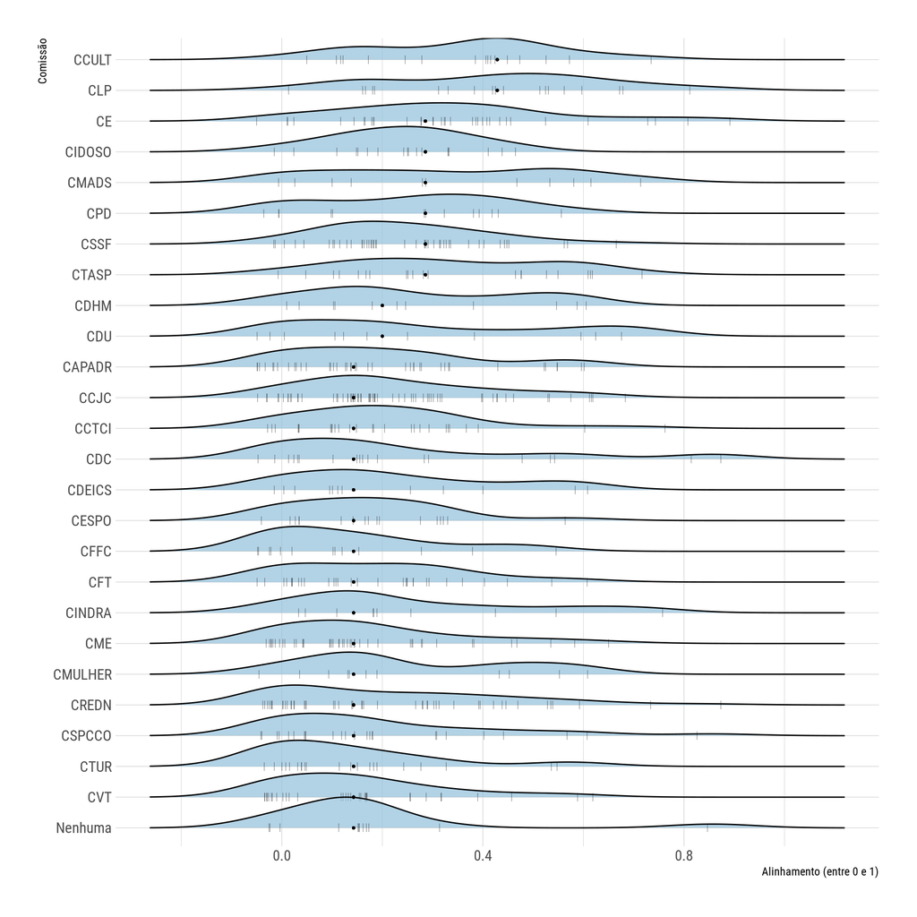

O ponto preto na visualização indica a mediana dos alinhamentos dos componentes da Comissão.

Pela visualização é notável que a concentração de deputados com alinhamento ao meio ambiente ocorre em valores abaixo de 50%. A Comissão com a maior mediana de alinhamento com relação a seus integrantes é a CCULT com 42.9% de alinhamento.